# IODS course project

# 2) Preparing the data for Linear Discriminant Analysis

First, I will standardize the dataset and print out summaries of the scaled data (below).

```r
# center and standardize variables
boston_scaled <- scale(Boston)

# summaries of the scaled variables
summary(boston_scaled)
```

```
##       crim                 zn               indus              chas
##  Min.   :-0.419367   Min.   :-0.48724   Min.   :-1.5563   Min.   :-0.2723
##  1st Qu.:-0.410563   1st Qu.:-0.48724   1st Qu.:-0.8668   1st Qu.:-0.2723
##  Median :-0.390280   Median :-0.48724   Median :-0.2109   Median :-0.2723
##  Mean   : 0.000000   Mean   : 0.00000   Mean   : 0.0000   Mean   : 0.0000
##  3rd Qu.: 0.007389   3rd Qu.: 0.04872   3rd Qu.: 1.0150   3rd Qu.:-0.2723
##  Max.   : 9.924110   Max.   : 3.80047   Max.   : 2.4202   Max.   : 3.6648
##       nox                rm               age               dis
##  Min.   :-1.4644   Min.   :-3.8764   Min.   :-2.3331   Min.   :-1.2658
##  1st Qu.:-0.9121   1st Qu.:-0.5681   1st Qu.:-0.8366   1st Qu.:-0.8049
##  Median :-0.1441   Median :-0.1084   Median : 0.3171   Median :-0.2790
##  Mean   : 0.0000   Mean   : 0.0000   Mean   : 0.0000   Mean   : 0.0000
##  3rd Qu.: 0.5981   3rd Qu.: 0.4823   3rd Qu.: 0.9059   3rd Qu.: 0.6617
##  Max.   : 2.7296   Max.   : 3.5515   Max.   : 1.1164   Max.   : 3.9566
##       rad               tax             ptratio            black
##  Min.   :-0.9819   Min.   :-1.3127   Min.   :-2.7047   Min.   :-3.9033
##  1st Qu.:-0.6373   1st Qu.:-0.7668   1st Qu.:-0.4876   1st Qu.: 0.2049
##  Median :-0.5225   Median :-0.4642   Median : 0.2746   Median : 0.3808
##  Mean   : 0.0000   Mean   : 0.0000   Mean   : 0.0000   Mean   : 0.0000
##  3rd Qu.: 1.6596   3rd Qu.: 1.5294   3rd Qu.: 0.8058   3rd Qu.: 0.4332
##  Max.   : 1.6596   Max.   : 1.7964   Max.   : 1.6372   Max.   : 0.4406
##      lstat              medv
##  Min.   :-1.5296   Min.   :-1.9063
##  1st Qu.:-0.7986   1st Qu.:-0.5989
##  Median :-0.1811   Median :-0.1449
##  Mean   : 0.0000   Mean   : 0.0000
##  3rd Qu.: 0.6024   3rd Qu.: 0.2683
##  Max.   : 3.5453   Max.   : 2.9865
```

```r
# change the object to data frame
boston_scaled <- as.data.frame(boston_scaled)
```

**Description:** The dataset is now scaled by subtracting the column means from the corresponding columns and dividing the difference with standard deviation. The values of the variables are now standardized, and we can see their values are now much closer to each other than with the unscaled dataset.

Next, I will create a categorical variable of the scaled crime rate in the dataset, using the quantiles as break points in the categorical variable.

```r
# summary of the scaled crime rate
summary(boston_scaled$crim)
```

```
##      Min.   1st Qu.    Median      Mean   3rd Qu.      Max.
## -0.419367 -0.410563 -0.390280  0.000000  0.007389  9.924110
```

```r
# create a quantile vector of crim and print it
bins <- quantile(boston_scaled$crim)
bins
```

```
##           0%          25%          50%          75%         100%
## -0.419366929 -0.410563278 -0.390280295  0.007389247  9.924109610
```

```r
# create a categorical variable 'crime'
crime <- cut(boston_scaled$crim, breaks = bins, include.lowest = TRUE, label = c("low", "med_low", "med_high", "high"))

# look at the table of the new factor crime
table(crime)
```

```
## crime
##      low  med_low med_high     high
##      127      126      126      127
```

```r
# remove original crim from the dataset
boston_scaled <- dplyr::select(boston_scaled, -crim)

# add the new categorical value to scaled data
boston_scaled <- data.frame(boston_scaled, crime)
```

**Description:** The variable crime is now a factor variable with levels low, med_low, med_high and high.

Next, I will divide the dataset to training and test sets, so that 80% of the data belongs to the train set.

```r
# number of rows in the Boston dataset
n <- nrow(boston_scaled)

# choose randomly 80% of the rows
ind <- sample(n,  size = n * 0.8)

# create training set
train <- boston_scaled[ind,]

# create test set
test <- boston_scaled[-ind,]
```

# 3) Linear Discriminant Analysis

I will fit the linear discriminant analysis on the train set created above, using the categorical crime rate as the target variable and all the other variables in the dataset as predictor variables.

```r
# linear discriminant analysis
lda.fit <- lda(crime ~ ., data = train)

# print the lda.fit object
lda.fit
```

```
## Call:
## lda(crime ~ ., data = train)
##
## Prior probabilities of groups:
##       low   med_low  med_high      high
## 0.2673267 0.2450495 0.2351485 0.2524752
##
## Group means:
##                   zn      indus        chas        nox          rm        age
## low       1.04938904 -0.9280136 -0.09005591 -0.8991895  0.43529694 -0.9165193
## med_low  -0.07774188 -0.2467422 -0.11325431 -0.5550010 -0.12333116 -0.3578433
## med_high -0.38614041  0.1495642  0.22498886  0.3775278  0.06918094  0.3912599
## high     -0.48724019  1.0171096 -0.07933396  1.0574965 -0.46559409  0.8548599
##                 dis        rad        tax     ptratio      black       lstat
## low       0.9317108 -0.6926276 -0.7272611 -0.47771978  0.3778198 -0.77206183
## med_low   0.3394218 -0.5480059 -0.4409590 -0.03498269  0.3097247 -0.15407163
## med_high -0.3480834 -0.4161001 -0.3164400 -0.21673423  0.1082619  0.04402853
## high     -0.8569242  1.6382099  1.5141140  0.78087177 -0.6707603  0.92392694
##                  medv
## low       0.513906648
## med_low   0.006537163
## med_high  0.124619775
## high     -0.699758037
##
## Coefficients of linear discriminants:
##                  LD1         LD2         LD3
## zn       0.083582760  0.72415127 -0.87678479
## indus   -0.001352858 -0.20419655  0.48759741
## chas    -0.111597737 -0.10442734 -0.07101076
## nox      0.389236558 -0.71846646 -1.43249179
## rm      -0.075049446 -0.08877696 -0.16038162
## age      0.282616312 -0.29924738 -0.17436855
## dis     -0.030824132 -0.28255097  0.12672719
## rad      3.378480098  0.95212391 -0.09657718
## tax      0.063485190  0.01856655  0.59481297
## ptratio  0.123218903 -0.05075159 -0.25780338
## black   -0.090599437  0.03840134  0.14183880
## lstat    0.262582696 -0.28826324  0.25901819
## medv     0.203219278 -0.43261438 -0.12379925
##
## Proportion of trace:
##    LD1    LD2    LD3
## 0.9558 0.0335 0.0107
```

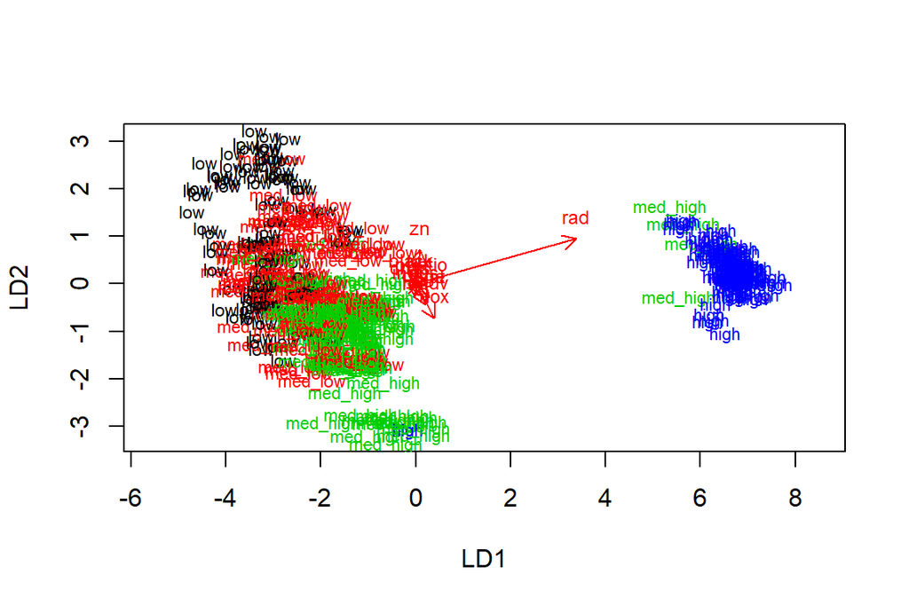

```r
# the function for lda biplot arrows
lda.arrows <- function(x, myscale = 1, arrow_heads = 0.1, color = "red", tex = 0.75, choices = c(1,2)){
  heads <- coef(x)
  arrows(x0 = 0, y0 = 0,
         x1 = myscale * heads[,choices[1]],
         y1 = myscale * heads[,choices[2]], col=color, length = arrow_heads)
  text(myscale * heads[,choices], labels = row.names(heads),
       cex = tex, col=color, pos=3)
}

# target classes as numeric
classes <- as.numeric(train$crime)

# plot the lda results
plot(lda.fit, dimen = 2, col = classes, pch = classes)
lda.arrows(lda.fit, myscale = 1)
```

Next, I will predict the crime classes with the LDA model on the test data.

```r
# first, save the correct classes from test data
correct_classes <- test$crime

# remove the crime variable from test data
test <- dplyr::select(test, -crime)

# then, predict classes with test data
lda.pred <- predict(lda.fit, newdata = test)

# cross tabulate the results
table(correct = correct_classes, predicted = lda.pred$class)
```

```
##           predicted
## correct    low med_low med_high high
##   low       10       9        0    0
##   med_low    4      17        6    0
##   med_high   0       6       23    2
##   high       0       0        0   25
```

**Description:** The LDA model does quite a good job at predicting the crime classes on the test data. When the correct class is low, the model predicts mostly correctly. When the correct class is med_low, most predictions are still correct, but now there are predictions in three different categories. When the correct class is med_high, again the model predicts mostly correctly. When the class is high, the model predicts all cases correctly. Therefore, the model is at its best when predicting the high crime rate class.